# R-Tutorial

31 October 2016

## History of R

R is a programming language that was created for statistical computing and graphics. It is a GNU project and it is considered to be a different implementation of the S programming language which was created by John Chambers.

R was developed by Robert Genteleman and Ross Ihaka and it was named after their first names and as a play on the name S. The initial version was realeased in 1995. Nowadays, R is developed and maintained by the R Core team, member of which is John Chambers.

## GNU Project

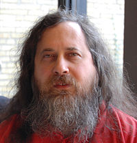

The GNU project was announced on 27 Sept 1983 by Richard Stallman at MIT. It is a free software, mass collaboration project, aimed to give users the freedom to use software with the following rights:

- Run software
- Share software (copy, distribute)
- study
- modify

And therefore free software was created (free to imply freedom).

## Presentation Structure

This presentation follows the structure of the book "Advanced-R" by Hadley Wickham. If you want to dive into deep waters with R, the book is highly recommented.

The book is available for free at http://adv-r.had.co.nz/.

## Chapter 1

Data Types and Data Structures

## Data Types

```r
typeof('Hello World')
```

```
## [1] "character"
```

```r
typeof(5)
```

```
## [1] "double"
```

```r
typeof(5L)
```

```
## [1] "integer"
```

```r
typeof(TRUE)
```

```
## [1] "logical"
```

Any more?

## Data Structures in Base R

- 1 Dimensional
  - Atomic Vector
  - List
  - Factor
- 2 Dimensional
  - Matrix
  - Dataframe
- Multi Dimensional
  - Array
  - Nested Lists

## 1 Dimensional Data Structures p.1

```r
#atomic vector
c(1, 2, 3)
```

```
## [1] 1 2 3
```

```r
#list
list(1, 'a', TRUE)
```

```
## [[1]]
## [1] 1
##
## [[2]]
## [1] "a"
##
## [[3]]
## [1] TRUE
```

## 1 Dimensional Data Structures p.2

```r
#factor
factor(letters[1:5])
```

```
## [1] a b c d e
## Levels: a b c d e
```

## 2 Dimensional Data Structures

```r
#matrix
matrix(1:12, ncol = 4)
```

```
##      [,1] [,2] [,3] [,4]
## [1,]    1    4    7   10
## [2,]    2    5    8   11
## [3,]    3    6    9   12
```

```r
#data.frame
data.frame(a = 1:3, b = letters[1:3])
```

```
##   a b
## 1 1 a
## 2 2 b
## 3 3 c
```

## Multi Dimensional Data Structures

```r
#array
array(1:8, c(2, 2, 2))
```

```
## , , 1
##
##      [,1] [,2]
## [1,]    1    3
## [2,]    2    4
##
## , , 2
##
##      [,1] [,2]
## [1,]    5    7
## [2,]    6    8
```

```r
#nested lists
list(list('a'),
     list(data.frame(a = 1:2)),
     list(letters[1:5]))
```

```
## [[1]]
## [[1]][[1]]
## [1] "a"
##
##
## [[2]]
## [[2]][[1]]
##   a
## 1 1
## 2 2
##
##
## [[3]]
## [[3]][[1]]
## [1] "a" "b" "c" "d" "e"
```

## Chapter Summary

4 Data Types

```
- Integer
- Character
- Double
- Logical
```

Structures:

|  | Homogenous | Heterogenous |
| --- | --- | --- |
| 1 Dimension | atomic vector | list |
| 2 Dimensions | matrix | data.frame |
| Multi Dimensional | array | nested lists |

## Coercion Rules

```r
c(1, 'Hello World')
```

```
## [1] "1"           "Hello World"
```

```r
c(1, TRUE)
```

```
## [1] 1 1
```

```r
c(TRUE, 3)
```

```
## [1] 1 3
```

```r
c(TRUE, 'Hello World', 1)
```

```
## [1] "TRUE"        "Hello World" "1"
```

logical < integer < double < character

## Chapter 2

Subsetting

## Subsetting

How many functions do you know?

- [
- [[
- $
- subset <– evil function

## [ function - 1 Dimension DS

```r
#1 Dimension - use only for atomic vectors or factors
#1:5 is an atomic vector (of type integer) containing numbers 1 to 5
#letters is a built-in dataset containing all the lower case latin letters
#subsetting letters returning the first 5 letters
letters[1:5]
```

```
## [1] "a" "b" "c" "d" "e"
```

```r
#same for factors
factor(letters)[1:5]
```

```
## [1] a b c d e
## Levels: a b c d e f g h i j k l m n o p q r s t u v w x y z
```

## [ function - 2 Dimensions DS p.1

```r
#use it for matrices
mymat <- matrix(1:9, ncol = 3)

#what do you think?
mymat[1:2]
```

```
## [1] 1 2
```

```r
#but
mymat[, 1:2]
```

```
##      [,1] [,2]
## [1,]    1    4
## [2,]    2    5
## [3,]    3    6
```

## [ function - 2 Dimensions DS p.2

```r
#use it for data.frames
mydat <- data.frame(a = 1:3, b = 4:6)

#what do you think?
mydat[1]
```

```
##   a
## 1 1
## 2 2
## 3 3
```

```r
#but
mydat[, 1]
```

```
## [1] 1 2 3
```

## [ function - 2 Dimensions DS p.2

```r
#also
mydat[3, 2]
```

```
## [1] 6
```

```r
#and
mydat[, 1:2]
```

```
##   a b
## 1 1 4
## 2 2 5
## 3 3 6
```

## [[ function - Use for lists

Can be used for 1 element.

```r
mylist <- list(abc = 'a', adb = 1, ba = c(1, 2))

#get first element
mylist[[1]]
```

```
## [1] "a"
```

```r
#can also chain
mylist[[3]][1]
```

```
## [1] 1
```

## $ function - Same as [[

The `$` function is the same sas `[[`.

Quoting from ?`$`:

Both `[[` and `$` select a single element of the list. The main difference is that `$` does not allow computed indices, whereas `[[` does. `x$name` is equivalent to `x[["name", exact = FALSE]]`.

```r
mylist$abc
```

```
## [1] "a"
```

```r
mylist$a
```

[output not shown]

```r
mylist$b
```

```
## [1] 1 2
```

## subset function - Use with caution

`subset` is a very popular function among beginners since it uses a function with the name subset which subconsciously makes it feel easier than using [, [[ and $. However, `subset` uses non-standard evaluation which makes it extremely dangerous for using in application development.

`subset` is only meant to be used in **interactive** sessions (i.e. when working on Rstudio, Rgui or similar IDE).

## Chapter Summary

Use [ for atomic vectors, factors, matrices and data.frames (at least until you feel comfortable with what they do for each data structure).

Use [[ and $ for lists at least at the beginning. Remember that a **data.frame is in reality a list of lists**!

Try not to use `subset` in general.

## Chapter 3

Vocabulary

## Vocabulary p.1

R is a functional programming language which means that a huge amount of functions exist already!

Part of mastering the R programming language is having a good vocabulary (otherwise you will find yourselves re-inventing the wheel on many occassions!).

I have included the most used functions below but ou can find a more comprehensive vocabulary guide here:

[Vocabulary](http://adv-r.had.co.nz/Vocabulary.html)

First Functions

```r
#most popular function
#http://stackoverflow.com/questions/1295955/what-is-the-most-useful-r-trick
#check structure of object
str
#see the documentation for function - same as help()
?
```

## Vocabulary p.2

Important Operators

```r
#is x in y?
%in%
#assignment operators
=, <-, <<-
#subset operators
$, [, [[, head, tail, subset
#evaluate expression in data environment
with
#get object from text
get
```

## Vocabulary p.3

Math Operators

```r
#calculations
*, +, -, /, ^, %%
#max, min, sum
max, min, sum
#statistics
mean, median, cor, sd, var
#comparison
<, >, <=, >=, !=, ==
```

## Vocabulary p.4

Functions used in function definitions

```r
#function definition
function
#missing argument - better to initiate with NULL
missing
#function returns
return, invisible
```

Logical Operators

```r
#and or xor not
&, |, xor, !
#all or any
all, any
```

## Vocabulary p.5

Data Structures or to do with data structures

```r
#data.structures
c, matrix, data.frame, list
#dimensions of data structures
length, dim, ncol, nrow
#binding
cbind, rbind
#making vectors
rev, rep, seq, sample
```

## Vocabulary p.6

Control Flow

```r
#ifs
if, if else, switch, ifelse
#loops
for, while, next, break
```

Apply and friends

```r
#simple apply in base R - for loop
apply,
#apply functions in C implementations (C implemented i.e. fast)
lapply, sapply, tapply
#personal favourite (also C implemented for-loop)
vapply
```

## Vocabulary p.7

Other Data Structures

```r
#factors
factor
#dates
as.Date, as.POSIXct, difftime
```

I/O

```r
#reading files
read.table, read.csv, load
#printing functions (also to files)
sink, capture.output, print, cat
#writing files
write.table, write.csv, save
```

## Chapter Summary

R is a functional programming language and therefore the more functions we know the easier it is to perform various actions in R. Mastering them takes time, but the more you use them the easier it will become!

## Chapter 4

Functions

## Functions

R in its core is a function programming language, so solid foundation of how functions work is essential when working with R.

John Chambers has said:

"To understand computations in R, two slogans are helpful:

- Everything that exists is an object.
- Everything that happens is a function call."

## Function Components

- the `body()` - the code inside the function.
- the `formals()` - the list of arguments which controls how you can call the function.
- the `environment()` the "map" of the location of the function's variables.

```r
#function double
#functions return the last evaluated object
#without needing to explicitly use return
double <- function(x) x * 2
body(double)
```

```
## x * 2
```

```r
formals(double)
```

[output not shown]

```r
environment(double)
```

```
## <environment: R_GlobalEnv>
```

## Lexical scoping

Scoping is the set of rules that govern how R looks up the value of a symbol. In the example below, scoping is the set of rules that R applies to go from the symbol x to its value 10:

```r
x <- 10
x
# [1] 10
```

Lexical scoping looks up symbol values based on how functions were nested when they were created, not how they are nested when they are called. With lexical scoping, you don't need to know how the function is called to figure out where the value of a variable will be looked up.

## Lexical Scoping - Principles

There are four basic principles behind R's implementation of lexical scoping:

- name masking
- functions vs. variables
- a fresh start
- dynamic lookup

## Name Masking

```r
f <- function() {
  x <- 1
  y <- 2
  c(x, y)
}
f()
```

```
## [1] 1 2
```

If a name isn't defined inside a function, R will look one level up.

```r
x <- 2
g <- function() {
  y <- 1
  c(x, y)
}
g()
```

```
## [1] 2 1
```

## Name Masking - Exercise

```r
x <- 1
h <- function() {
  y <- 2
  i <- function() {
    z <- 3
    c(x, y, z)
  }
  i()
}
h()
```

```
## [1] 1 2 3
```

## functions vs. variables

The same principles apply regardless of the type of associated value - finding functions works exactly the same way as finding variables:

```r
l <- function(x) x + 1
m <- function() {
  l <- function(x) x * 2
  l(10)
}
m()
```

```
## [1] 20
```

## A fresh start

```r
j <- function() {
  if (!exists("a")) {
    a <- 1
  } else {
    a <- a + 1
  }
  print(a)
}
j()
```

```
## [1] 1
```

```r
j()
```

```
## [1] 1
```